# Graph Inference via Canonical Correlation Analysis

LVP

Sunday, November 23, 2014

## Parametric version – Wilk’s Lambda

Consider a graph on $n$ vertices.

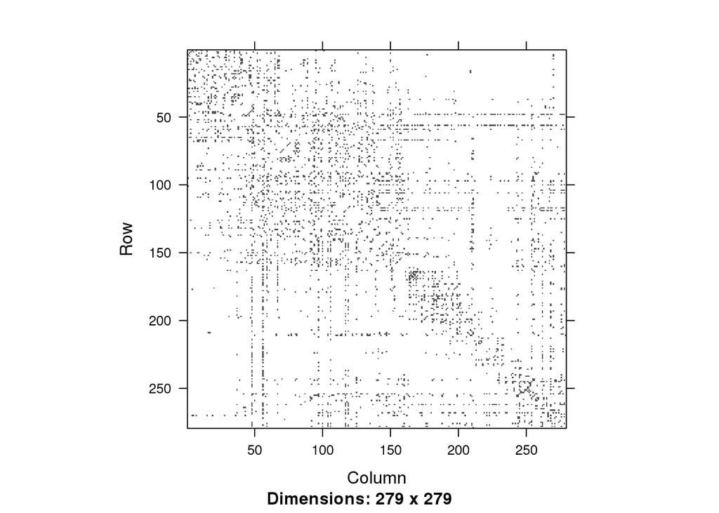

```r
rm(list=ls())
load('CelegansData.RData')
attach(CelegansData)
Gc = graph.adjacency(Ac,weighted = TRUE, mode = 'max')
Ge = graph.adjacency(Ae,weighted = TRUE, mode = 'max')

Ac = get.adjacency(Gc)
Ae = get.adjacency(Ge)
image(Ac)
```

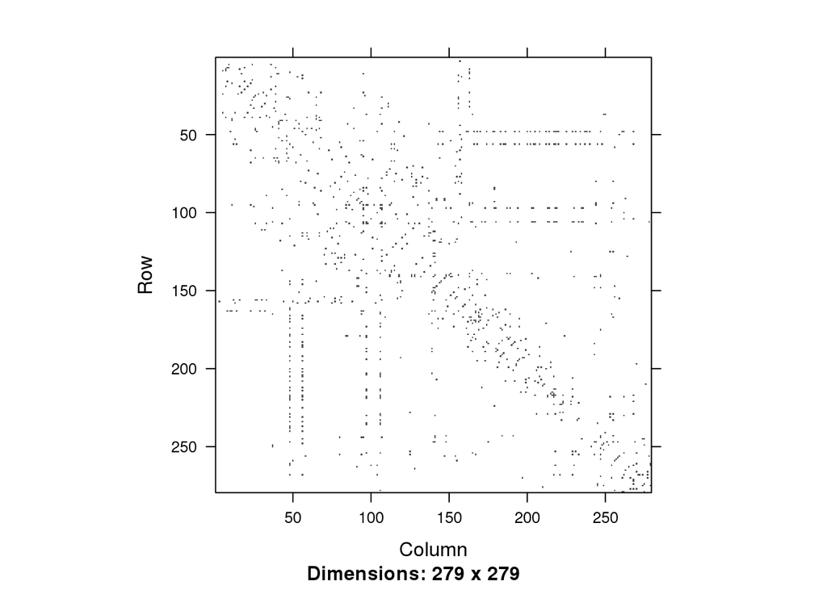

```r
image(Ae)
```

```r
dimc = 10
dime = 10
Xc = adjacency.spectral.embedding(Gc,no = dimc)$X
Xe = adjacency.spectral.embedding(Ge,no = dime)$X

#ggpairs(Xc)
#ggpairs(Xe)

cc1 <- cc(Xc,Xe)
cc1$cor
```

```
##  [1] 0.719177875 0.518951126 0.402130148 0.269346609 0.106408008
##  [6] 0.040930041 0.030980206 0.024825670 0.001410075 0.000464921
```

When choosing the *dimension* of the model, a popular technique is to a likelihood ratio test for $H_0: \Sigma_{12} = 0$ versus $H_1: \Sigma_{12} \neq 0$, where $\Sigma_{12}$ represents an off-diagonal block of the correlation matrix of the canonical covariates. For a detailed discussion, we refer the reader to (Johnson and Wichern 2002, 569–71), but we give a brief summary. In short, we reject $H_0: \Sigma_{12} = 0$ at significance level $\alpha$ if $- (n-1-\frac{1}{2} (p+q+1)) \ln \prod_{i=1}^p (1 - \widehat \rho_i^2) > \chi_{pq}^2(\alpha),$ where $\chi_{pq}^2(\alpha)$ is the upper $(100\alpha)$th percentile of a chi-square distribution with $pq$ d.f.  
If the null hypothesis $H_0: \Sigma_{12} = 0 \quad (eq.~\rho_1=\cdots=\rho_p = 0)$ is rejected, then, since the canonical correlation is ordered, we can begin by assuming that the first canonical correlation is nonzero and the remaining $p-1$ canonical correlations are zero. This allows us to entertain the following sequence of hypotheses: $\begin{aligned} &H_0^k: \rho_1\neq0,\cdots,\rho_k \neq 0, \rho_{k+1}=\cdots=\rho_p = 0 \\ &H_1^k: \rho_i\neq0, \text{ for some } i \ge k+1 \end{aligned}$ Then, for each $k$, we reject $H_0^k$ at level $\alpha$ if $- (n-1-\frac{1}{2} (p+q+1)) \ln \prod_{i=k+1}^p (1 - \widehat \rho_i^2) > \chi_{(p-k)(q-k)}^2(\alpha),$ where $\chi_{(p-k)(q-k)}^2(\alpha)$ is the upper $(100\alpha)$th percentile of a chi-square distribution with $(p-k)(q-k)$ d.f. The symbol in the listing below denote the **Wilks’ lambda**, which is a reduced form of a likelihood ratio statistic (c.f. (Johnson and Wichern 2002, 217)).

[output not shown]

```r
Sc = cc1$xcoef %*% diag(sqrt(diag(cov(Xc))))
Se = cc1$ycoef %*% diag(sqrt(diag(cov(Xe))))[1:k,1:k]
Sc[,1:2]
```

[output not shown]

```r
Se[,1:2]
```

[output not shown]

```r
#plt.cc(cc1)
```

## Non Parametric version – Distance Correlation

Our discussion in this section follows that of (Székely et al. 2007). We first begin with a demonstrative numerical simulation experiment.

The following listings define two building blocks of the distance correlation measure, with which we perform our test.

```r
myfun <- function(X) {
    nvertex = nrow(X)
    dX = as.matrix(dist(X),p=ncol(X))
    rm.dX = rowMeans(dX)
    cm.dX = colMeans(dX)
    gm.dX = matrix(mean(dX),nvertex,nvertex)
    rm.dX = foreach(itr=1:nvertex,.combine='rbind') %do% { rep(rm.dX[itr],nvertex) }
    cm.dX = foreach(itr=1:nvertex, .combine='cbind') %do% { rep(cm.dX[itr],nvertex)}

    dX - rm.dX - cm.dX + gm.dX
}

myfun2 <- function(X) {
    nvertex = nrow(X)
    (as.matrix(dist(X),p=ncol(X)))
}
```

In the code listing below, we perform Monte Carlo experiments for a sequence of pair of observations. First, we consider the case when the pair is independent. Second, we consider the case where the pair is correlated. We note that by (Székely et al. 2007), the test statistic has an asymptotic distribution invariant to the underlying distributions under the null hypothesis, i.e., the independence holds. As such, the distribution of the independence case can be approximate with  
the empirical distribution of the Monte Carlo replicates from the first experiment.

```r
set.seed(123)
numr = 20
numc = 1
nmc = 100

retval.ind = foreach(mcitr=1:nmc,.combine='c',.errorhandling = 'remove') %do% {
    Yc = matrix(rnorm(numr*numc),numr,numc)
    Ye = matrix(rnorm(numr*numc),numr,numc)
    nrow(Yc) * mean(myfun(Yc) * myfun(Ye))/(mean(myfun2(Yc)) * mean(myfun2(Ye)))
}

# to introduce more noise increase the value of my.p
my.p = 0
retval.dep = foreach(mcitr=1:nmc,.combine='c',.errorhandling = 'remove') %do% {
    Yc = matrix(rnorm(numr*numc),numr,numc)
    Ye = 1.0*(Yc > 0) + matrix(sample(0:1,numc*numr,prob=c(1-my.p,my.p),replace=TRUE),numr,numc)
    nrow(Yc) * mean(myfun(Yc) * myfun(Ye))/(mean(myfun2(Yc)) * mean(myfun2(Ye)))
}
```

The things related to the independent case is coded red, and the things related to the dependent case is coded blue. The vertical red color marks the critical value (using the empirical CDF).

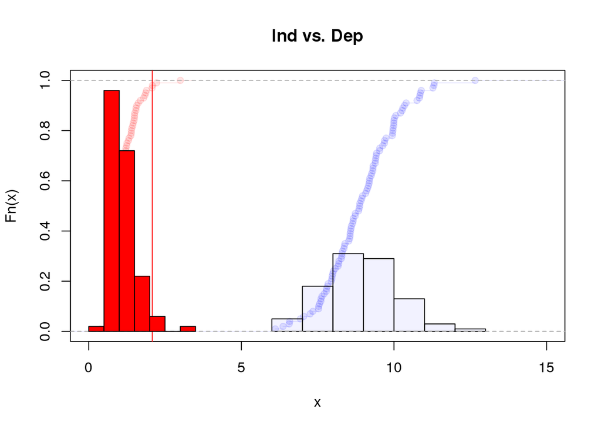

```r
plot(ecdf(retval.dep),col=rgb(0,0,1,0.1),xlim=c(0,15), main='Ind vs. Dep')
hist((retval.dep),add=TRUE,prob=TRUE,col=rgb(0,0,1,0.05))
plot(ecdf(retval.ind),col=rgb(1,0,0,0.1),add=TRUE)
abline(v=quantile(retval.ind,0.975),col=rgb(1,0,0,1))
hist((retval.ind),add=TRUE,prob=TRUE,col=rgb(1,0,0,1))
```

We now apply the aforementioned non-parametric tests on C.~elegan data.  
First we apply the test on the embeddings of the adjacency matrices of the chemical and the electrical, and the on the variables.

```r
mydata = data.frame(Xe=Xe,Xc=Xc)
for(itr in 1:(dimc-1)) {
    Yc = mydata[,(dimc-itr):dimc,drop=FALSE]
    Ye = mydata[,(dimc+dimc-itr):(dimc+dimc),drop=FALSE]
    Tc = myfun(Yc)
    Te = myfun(Ye)
    mystat = nrow(Yc) * mean(myfun(Yc) * myfun(Ye))/(mean(myfun2(Yc)) * mean(myfun2(Ye)))
    msg = sprintf('%d:%d, %f\n', dimc-itr,dimc,mystat)
    cat(msg)
}
```

```
## 9:10, 3.658606
## 8:10, 4.415889
## 7:10, 4.727389
## 6:10, 4.088100
## 5:10, 3.871641
## 4:10, 4.440151
## 3:10, 4.110352
## 2:10, 3.966611
## 1:10, 5.213075
```

```r
mydata2 = cbind(cc1$scores$xscores,cc1$scores$yscores)
mydata2 = as.data.frame(mydata2)
for(itr in 1:(dimc-1)) {
    Yc = mydata2[,(dimc-itr):dimc,drop=FALSE]
    Ye = mydata2[,(dimc+dimc-itr):(dimc+dimc),drop=FALSE]
    Tc = myfun(Yc)
    Te = myfun(Ye)
    mystat = nrow(Yc) * mean(myfun(Yc) * myfun(Ye))/(mean(myfun2(Yc)) * mean(myfun2(Ye)))
    msg = sprintf('%d:%d, %f\n', dimc-itr,dimc,mystat)
    cat(msg)
}
```

```
## 9:10, 0.953839
## 8:10, 1.026428
## 7:10, 1.270177
## 6:10, 1.160419
## 5:10, 1.431519
## 4:10, 2.410871
## 3:10, 3.016968
## 2:10, 4.152859
## 1:10, 5.125243
```

The reported values are the values of the test statistics.  
We observe that for the canonical correlation variables, using an asymptotic result in (Székely et al. 2007), our operating critical value at the level $\alpha=0.05$ is $1.96^2 = 3.8416$. This suggests that the values of the canonical correlation variables from the third position through the last position does support independence (rather non-association). However, the first two canonical variables appear to be significant enough to support the hypothesis that the first two are correlated. Given this observation, the output from the raw data is not surprising. Note that this is consistent with our earlier result using Wilk’s Lambda.

## Non Parametric version – Permutation Tests

For details on the algorithm used for permutation tests used in this section, see (Hothorn et al. 2008).

For simulation experiments,

```r
correxam <- data.frame(x = rnorm(7), y = rnorm(7))
ip = new('IndependenceProblem',y=rotarod["time"], x=rotarod['group'])
sexact <-function(obj) {
    x <-obj@xtrans
    y <-obj@ytrans
    perms <- permutations(nrow(x))
    pstats <- apply(perms,1,function(p) sum(x[p,]*y))
    pstats <- (pstats - expectation(obj)) / sqrt(variance(obj))
    p <- function(q) 1 - mean(pstats > q)
    new("PValue", p=p, pvalue=p)
}
independence_test(y~x, data=correxam,alternative = 'less',distribution = sexact)
```

```
##
##  General Independence Test
##
## data:  y by x
## Z = 0.8809, p-value = 0.8012
## alternative hypothesis: less
```

Using the raw data:

```r
myout = foreach(itr = 1:(dimc-1),.combine = 'rbind') %dopar% {
    lhs = paste(paste0('Xc.',(dimc-itr):(dimc)),collapse = ' + ')
    rhs = paste(paste0('Xe.',(dime -itr):(dime)),collapse = ' + ')
    myform = as.formula(paste(lhs,rhs, sep = ' ~ '))
    mystat = pvalue(independence_test(myform, data = mydata, alternative = 'two.sided'))
    c(dimc-itr,dimc,mystat)
}
for(itr in 1:(dimc-1)) {
    msg = sprintf('%d:%d, %f\n', dimc-itr,dimc,myout[itr,3])
    cat(msg)
}
```

```
## 9:10, 0.114748
## 8:10, 0.001046
## 7:10, 0.001859
## 6:10, 0.002903
## 5:10, 0.004178
## 4:10, 0.000092
## 3:10, 0.000120
## 2:10, 0.000026
## 1:10, 0.000000
```

Using the reduced data:

```r
colnames(mydata2) = colnames(mydata)

myout2 = foreach(itr = 1:(dimc-1),.combine = 'rbind') %dopar% {
    lhs = paste(paste0('Xc.',(dimc-itr):(dimc)),collapse = ' + ')
    rhs = paste(paste0('Xe.',(dime -itr):(dime)),collapse = ' + ')
    myform = as.formula(paste(lhs,rhs, sep = ' ~ '))
    mystat = pvalue(independence_test(myform, data = mydata2, teststat='quad', alternative = 'two.sided',distribution = 'asymptotic'))
    c(dimc-itr,dimc,mystat)
}
for(itr in 1:(dimc-1)) {
    msg = sprintf('%d:%d, %f\n', dimc-itr,dimc,myout2[itr,3])
    cat(msg)
}
```

```
## 9:10, 1.000000
## 8:10, 1.000000
## 7:10, 1.000000
## 6:10, 1.000000
## 5:10, 1.000000
## 4:10, 0.998860
## 3:10, 0.307043
## 2:10, 0.000021
## 1:10, 0.000000
```

## Further exploration of C. elegan Data

```r
Xf=cbind(CelegansData$Vcols)

for(itr in 1:10) {
    msg = (nrow(Xc) * mean(myfun(Xc[,itr:10,drop=FALSE]) * myfun(Xf))/(mean(myfun2(Xc[,itr:10,drop=FALSE])) * mean(myfun2(Xf))))
    cat(itr,": 10","\t",msg,'\n')
}
```

```
## 1 : 10    10.15104
## 2 : 10    9.677785
## 3 : 10    9.221988
## 4 : 10    10.3966
## 5 : 10    10.28876
## 6 : 10    10.35363
## 7 : 10    10.35882
## 8 : 10    10.58207
## 9 : 10    10.31588
## 10 : 10   9.543611
```

```r
for(itr in 1:10) {
    msg = (nrow(Xe) * mean(myfun(Xe[,itr:10,drop=FALSE]) * myfun(Xf))/(mean(myfun2(Xe[,itr:10,drop=FALSE])) * mean(myfun2(Xf))))
    cat(itr,": 10","\t",msg,'\n')
}
```

```
## 1 : 10    6.217716
## 2 : 10    5.587154
## 3 : 10    5.768976
## 4 : 10    6.1995
## 5 : 10    4.576867
## 6 : 10    4.756992
## 7 : 10    5.058598
## 8 : 10    3.947796
## 9 : 10    2.981981
## 10 : 10   2.868103
```

```r
for(itr in 1:10) {
    msg = (nrow(Yc) * mean(myfun(Yc[,itr:10,drop=FALSE]) * myfun(Xf))/(mean(myfun2(Yc[,itr:10,drop=FALSE])) * mean(myfun2(Xf))))
    cat(itr,": 10","\t",msg,'\n')
}
```

```
## 1 : 10    10.04557
## 2 : 10    11.43345
## 3 : 10    11.13326
## 4 : 10    11.03929
## 5 : 10    10.00971
## 6 : 10    9.514063
## 7 : 10    8.656414
## 8 : 10    8.493296
## 9 : 10    7.920997
## 10 : 10   8.230316
```

```r
for(itr in 1:10) {
    msg = (nrow(Ye) * mean(myfun(Ye[,itr:10,drop=FALSE]) * myfun(Xf))/(mean(myfun2(Ye[,itr:10,drop=FALSE])) * mean(myfun2(Xf))))
    cat(itr,": 10","\t",msg,'\n')
}
```

```
## 1 : 10    5.995332
## 2 : 10    6.035192
## 3 : 10    4.356497
## 4 : 10    4.170431
## 5 : 10    3.166962
## 6 : 10    3.031907
## 7 : 10    2.793575
## 8 : 10    2.672751
## 9 : 10    3.029342
## 10 : 10   0.9963914
```

Note that the question of independence between $Ae$ and $Ac$ is not the same as the question of whether or not $Ae$ and $Ac$ have the same mean. The next experiment suggests that $Ac$ and $Ae$ has the same mean, and the approach taken is via a model selection technique using information criteria.

```r
X = cBind(Ac=as.vector(Ac),Ae=as.vector(Ae))
foreach(itr=1:2,.combine='rbind') %do% {
    getAICc(gclust.rsvt(X,itr,nmfmethod = 'pe-nmf',alpha=0,beta=0.1))
}
#  nclust negloglikpart parampart      AIC
#1      1      29.58195  1.848173 31.43013
#2      2      30.42586  4.334048 34.75991
```

References

Hothorn, Torsten, Kurt Hornik, Mark A. van de Wiel, and Achim Zeileis. 2008. “Implementing a Class of Permutation Tests: The Coin Package.” *Journal of Statistical Software* 28 (8): 1–23. http://www.jstatsoft.org/v28/i08.

Johnson, R.A., and D.W. Wichern. 2002. *Applied Multivariate Statistical Analysis*. Applied Multivariate Statistical Analysis v. 1. Prentice Hall. http://books.google.com/books?id=VlcZAQAAIAAJ.

Székely, Gábor J, Maria L Rizzo, Nail K Bakirov, and others. 2007. “Measuring and Testing Dependence by Correlation of Distances.” *The Annals of Statistics* 35 (6). Institute of Mathematical Statistics: 2769–94.